# Estimate metabolic index parameters

Max Lindmark

12 March, 2023

# Intro

Fit models à la Essington (2022) to acquire metabolic index parameters from a mixed GLMM (glmmTMB), leveraging information from species with lots of experimental data. Save metabolic index params and export as csv.

## Load packages & source functions

```r
# Load libraries, install if needed
library(tidyverse)
library(readxl)
library(tidylog)
library(RCurl)
library(devtools)
library(glmmTMB)
library(rMR)
library(RColorBrewer)
```

```r
library(patchwork)

# Source code for plots
source_url("https://raw.githubusercontent.com/maxlindmark/spatial-metabolic-index/main/R/functions/map-plot.R")
theme_set(theme_plot())
```

# Intro

```r
# https://github.com/fate-spatialindicators/SDM_O2/blob/master/code/estimate_mi_parameters.R

# Read data
o2 <- readr::read_delim("https://raw.githubusercontent.com/maxlindmark/spatial-metabolic-index/main/data/essington_pO2_extended.csv", delim = ";") %>%
  dplyr::select(-comment)
unique(o2$source)
```

```
#> [1] "Essington2022" "Lindmark"
```

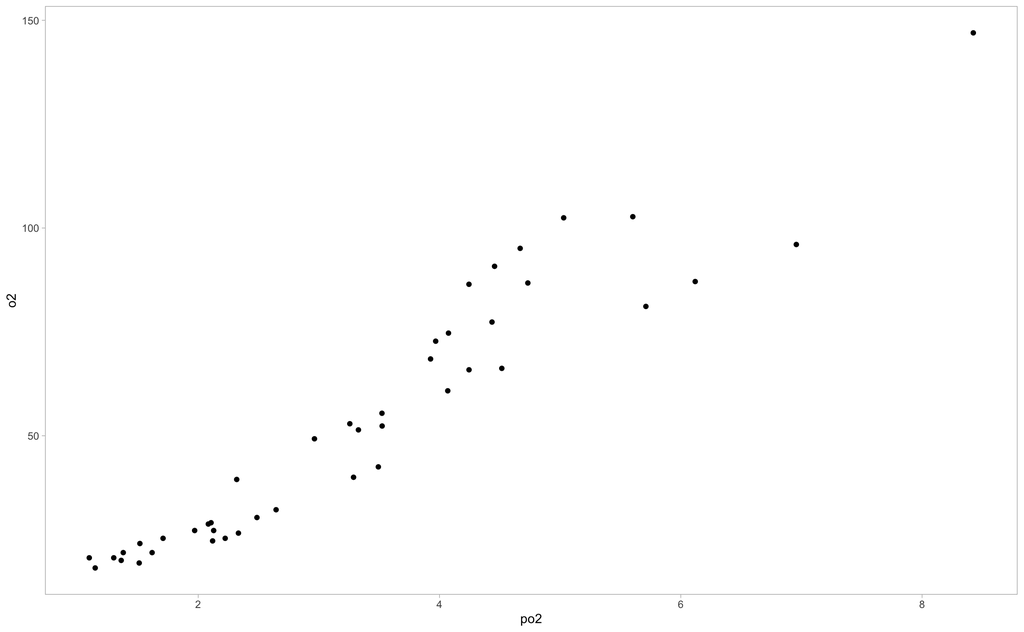

```r
# Now we need to standardize units across experimental data
spc_list <- unique(o2$spc)

c_to_K <- function(x) x + 273.15

# TODO: check salinity units in Essington data, not sure it's correct + my values are in pp.thou
# Get the experimental data in po2
o2$po2 <- NA
for (i in 1:length(spc_list)) {

  spc_index <- which(o2$spc == spc_list[i])

  tmp_dat <- dplyr::filter(o2, spc == spc_list[i])

  tmp_dat$po2 <- DO.unit.convert(tmp_dat$lc50,
                                 DO.units.in = tmp_dat$units[1],
                                 DO.units.out = "PP",
                                 bar.press = 1,
                                 bar.units.in = "atm",
                                 temp.C = tmp_dat$temp,
                                 bar.units.out = "kpa",
                                 salinity = tmp_dat$salinity[1],
                                 salinity.units = "uS")

  o2$po2[spc_index] <- tmp_dat$po2

}

# Get the experimental data in unit mg/L
o2$o2 <- NA

for (i in 1:length(spc_list)) {

  spc_index <- which(o2$spc == spc_list[i])

  tmp_dat <- dplyr::filter(o2, spc == spc_list[i])

  tmp_dat$o2 <- DO.unit.convert(tmp_dat$lc50,
                                DO.units.in = tmp_dat$units[1],
                                DO.units.out = "mg/L",
                                bar.press = 1,
                                bar.units.in = "atm",
                                temp.C = tmp_dat$temp,
                                bar.units.out = "kpa",
                                salinity = tmp_dat$salinity[1],
                                salinity.units = "uS")

  o2$o2[spc_index] <- tmp_dat$o2

}

# Now convert to convert oxygen from mg/L -> ml/L -> micro mol/l
# 1 mg/l = 22.391 ml/31.998 = 0.700 ml/l
# https://www.ices.dk/data/tools/Pages/Unit-conversions.aspx

o2$o2 <- ((o2$o2*0.7) * (10^3)) / 22.391

o2$spc <- as.factor(o2$spc)
nspc <- length(levels(o2$spc))

ggplot(o2, aes(po2, o2)) +
  geom_point()
```

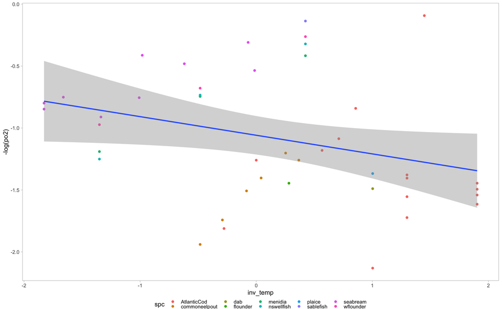

```r
# Add Boltzmann-Arrhenius temperature
tref <- 15 # arbitrary reference temperature
kb <- 0.000086173324 # Boltsmann's constant in unit Ev
o2$inv_temp <- (1 / kb)  * ( 1 / (o2$temp + 273.15) - 1 / (tref + 273.15))

# Plot the data we want to fit
o2 %>%
  ggplot(aes(inv_temp, -log(po2), color = spc)) +
  geom_point() +
  geom_smooth(aes(inv_temp, -log(po2)), method = "lm", inherit.aes = FALSE)
```

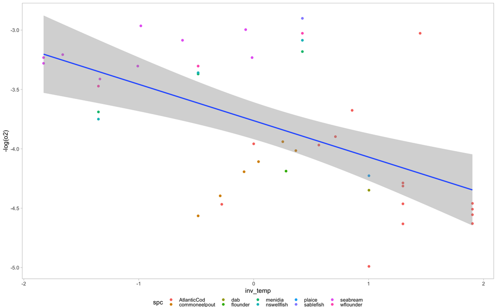

```r
o2 %>%
  ggplot(aes(inv_temp, -log(o2), color = spc)) +
  geom_point() +
  geom_smooth(aes(inv_temp, -log(o2)), method = "lm", inherit.aes = FALSE)
```

```
#> filter: removed 26 rows (60%), 17 rows remaining
```

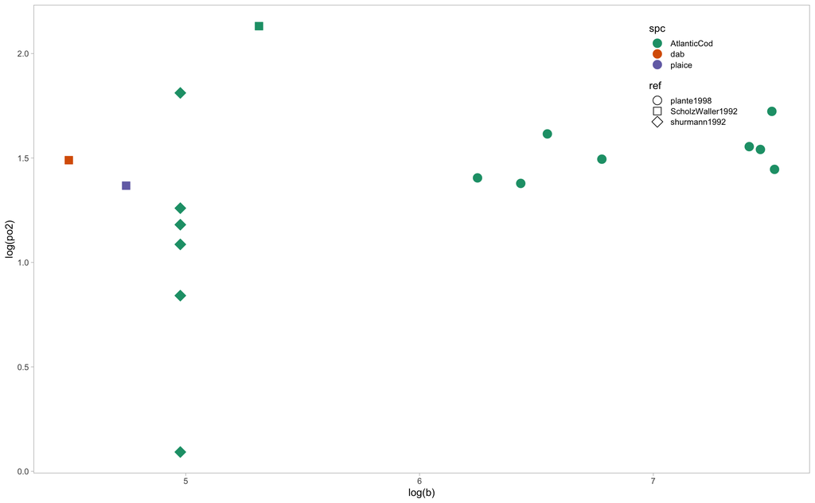

```r
o2 %>%
  filter(spc %in% c("AtlanticCod", "plaice", "dab")) %>%
  ggplot(aes(log(b), log(po2), shape = ref, fill = spc, color = spc)) +
  geom_point(size = 4) +
  scale_shape_manual(values = c(21:24)) +
  scale_color_brewer(palette = "Dark2") +
  scale_fill_brewer(palette = "Dark2") +
  theme(legend.position = c(0.85, 0.85))
```

The last plot illustrates the issue with cod. We know from regional experiments that Baltic cod have a higher critical oxygen, but if we use experiments by Plante using cod from the Western Atlantic, we will estimate them to be MORE oxygen tolerant than Baltic flatfishes. We don’t have enough data to estimate both a random species intercept and a “reference” effect. So what I’ll do is that I use the original Essington data to estimate the size and temperature dependence of (p)O2 crit, and then use those estimates to temperature-correct the Baltic experimental data (which anyway don’t have mass or temperature variation, so removing them from the data set is a small loss.)

```r
o2_og <- o2 %>%
  filter(source == "Essington2022")
```

```
#> filter: removed 4 rows (9%), 39 rows remaining
```

```r
# Fit model to Eq.2 in Essington (2022). Fixed effects of mass and temperature
# oxygen in unit pp
fit_po2 <- glmmTMB(-log(po2) ~ (1|spc) + log(b) + inv_temp,
                   data = o2_og,
                   family = gaussian(link = "identity"))

summary(fit_po2)
```

```
#>  Family: gaussian  ( identity )
#> Formula:          -log(po2) ~ (1 | spc) + log(b) + inv_temp
#> Data: o2_og
#>
#>      AIC      BIC   logLik deviance df.resid
#>     30.9     39.2    -10.4     20.9       34
#>
#> Random effects:
#>
#> Conditional model:
#>  Groups   Name        Variance Std.Dev.
#>  spc      (Intercept) 0.52303  0.7232
#>  Residual             0.05074  0.2253
#> Number of obs: 39, groups:  spc, 7
#>
#> Dispersion estimate for gaussian family (sigma^2): 0.0507
#>
#> Conditional model:
#>             Estimate Std. Error z value Pr(>|z|)
#> (Intercept)  0.26978    0.35195   0.767    0.443
#> log(b)      -0.29830    0.05894  -5.062 4.16e-07 ***
#> inv_temp     0.44802    0.07314   6.126 9.03e-10 ***
#> ---
#> Signif. codes:  0 '***' 0.001 '**' 0.01 '*' 0.05 '.' 0.1 ' ' 1
```

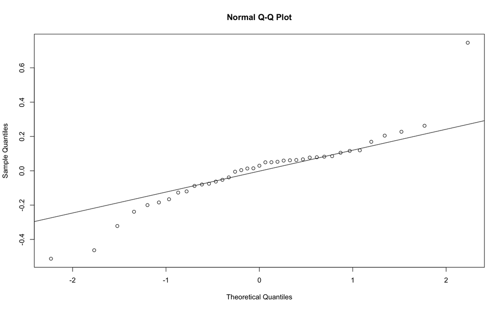

```r
res_po2 <- residuals(fit_po2)
qqnorm(res_po2); qqline(res_po2)
```

```r
# oxygen in unit micro mol / L
fit_o2 <- glmmTMB(-log(o2) ~ (1|spc) + log(b) + inv_temp,
                  data = o2_og,
                  family = gaussian(link = "identity"))

summary(fit_o2)
```

```
#>  Family: gaussian  ( identity )
#> Formula:          -log(o2) ~ (1 | spc) + log(b) + inv_temp
#> Data: o2_og
#>
#>      AIC      BIC   logLik deviance df.resid
#>     31.7     40.0    -10.8     21.7       34
#>
#> Random effects:
#>
#> Conditional model:
#>  Groups   Name        Variance Std.Dev.
#>  spc      (Intercept) 0.52522  0.7247
#>  Residual             0.05191  0.2278
#> Number of obs: 39, groups:  spc, 7
#>
#> Dispersion estimate for gaussian family (sigma^2): 0.0519
#>
#> Conditional model:
#>             Estimate Std. Error z value Pr(>|z|)
#> (Intercept) -2.42807    0.35419  -6.855 7.11e-12 ***
#> log(b)      -0.29977    0.05968  -5.023 5.08e-07 ***
#> inv_temp     0.29388    0.07402   3.970 7.18e-05 ***
#> ---
#> Signif. codes:  0 '***' 0.001 '**' 0.01 '*' 0.05 '.' 0.1 ' ' 1
```

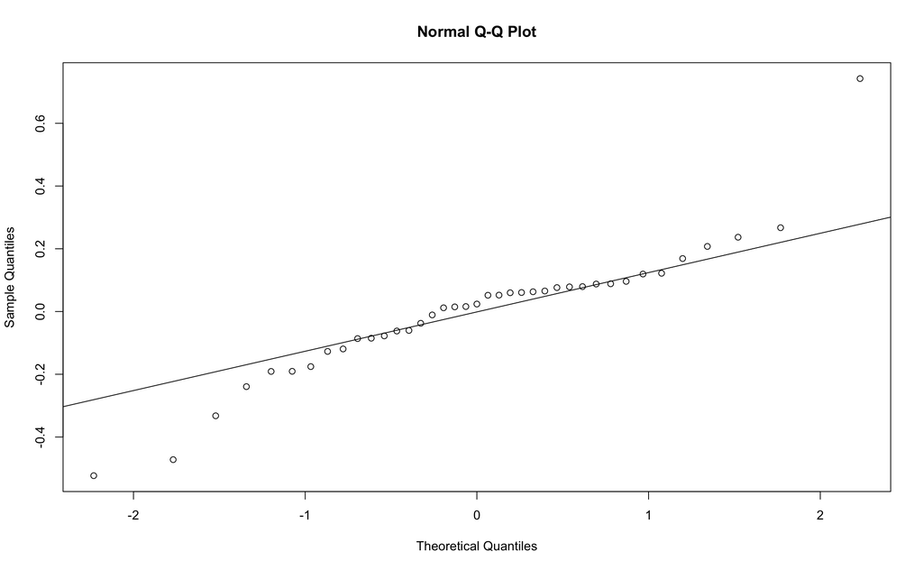

```r
res_o2 <- residuals(fit_o2)
qqnorm(res_o2)
qqline(res_o2)
```

```r
# Now we can mass and temperature correct (p)O2 in Baltic experiments by using Essingtons Eq. 2., but re-arranging it so that we have log(Ao) on the LHS. I.e., by assuming that phi = 1 is equal to critical o2, and we have data for critical o2, we can calculate Ao from the other parameters
fe_o2 <- tibble(term = names(fixef(fit_o2)$cond),
                est = fixef(fit_o2)$cond) %>%
  filter(term %in% c("log(b)", "inv_temp")) %>%
  pivot_wider(names_from = "term", values_from = est) %>%
  rename(n_o2 = `log(b)`,
         E_o2 = inv_temp)
```

```
#> filter: removed one row (33%), 2 rows remaining
#> pivot_wider: reorganized (term, est) into (log(b), inv_temp) [was 2x2, now 1x2]
#> rename: renamed 2 variables (n_o2, E_o2)
```

```r
fe_po2 <- tibble(term = names(fixef(fit_po2)$cond),
             est = fixef(fit_po2)$cond) %>%
  filter(term %in% c("log(b)", "inv_temp")) %>%
  pivot_wider(names_from = "term", values_from = est) %>%
  rename(n_po2 = `log(b)`,
         E_po2 = inv_temp)
```

```
#> filter: removed one row (33%), 2 rows remaining
#> pivot_wider: reorganized (term, est) into (log(b), inv_temp) [was 2x2, now 1x2]
#> rename: renamed 2 variables (n_po2, E_po2)
```

```r
o2_new <- o2 %>%
  filter(source == "Lindmark") %>%
  dplyr::select(spc, b, inv_temp, temp, po2, o2)
```

```
#> filter: removed 39 rows (91%), 4 rows remaining
```

```r
o2_new <- o2_new %>%
  mutate(A0_o2 = exp(-fe_o2$E_o2*inv_temp - log(o2) -fe_o2$n_o2*log(b)),
         A0_po2 = exp(-fe_po2$E_po2*inv_temp - log(po2) -fe_po2$n_po2*log(b)))
```

```
#> mutate: new variable 'A0_o2' (double) with 4 unique values and 0% NA
#>         new variable 'A0_po2' (double) with 4 unique values and 0% NA
```

```r
o2_new
```

```
#> # A tibble: 4 × 8
#>   spc             b inv_temp  temp   po2    o2  A0_o2 A0_po2
#>   <fct>       <dbl>    <dbl> <dbl> <dbl> <dbl>  <dbl>  <dbl>
#> 1 plaice      115      1.00      8  3.93  68.5 0.0451  0.669
#> 2 AtlanticCod 203      1.00      8  8.42 147.  0.0249  0.370
#> 3 dab          90      1.00      8  4.44  77.4 0.0371  0.551
#> 4 flounder      0.6    0.281    13  4.24  65.9 0.0120  0.178
```

```r
# Check if correct (if we can recreate the random intercepts using this manual correction)
re_po2 <- data.frame(spc = row.names(ranef(fit_po2)$cond$spc),
                     est = ranef(fit_po2)$cond$spc$`(Intercept)`) %>%
  mutate(A0_po2 = exp(fixef(fit_po2)$cond[1] + est))
```

```
#> mutate: new variable 'A0_po2' (double) with 7 unique values and 0% NA
```

```r
o2_og <- o2_og %>%
  mutate(A0_po2 = exp(-fe_po2$E_po2*inv_temp - log(po2) - fe_po2$n_po2*log(b)))
```

```
#> mutate: new variable 'A0_po2' (double) with 39 unique values and 0% NA
```

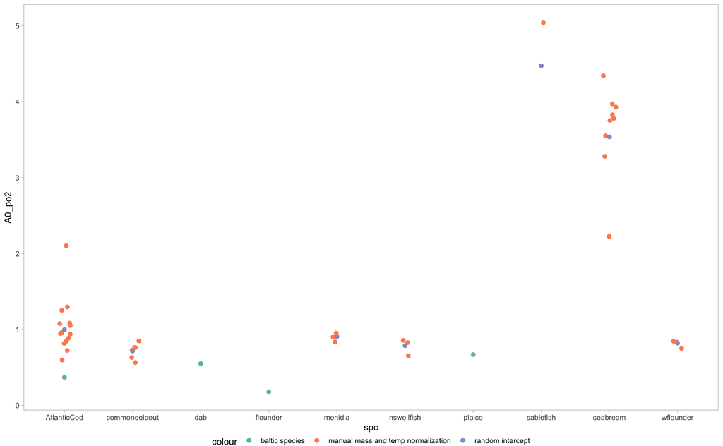

```r
ggplot(o2_og, aes(spc, A0_po2, color = "manual mass and temp normalization")) +
  geom_jitter(height = 0, width = 0.1, size = 2) +
  geom_point(data = re_po2, aes(spc, A0_po2, color = "random intercept"), size = 2) +
  geom_point(data = o2_new, aes(spc, A0_po2, color = "baltic species"), size = 2) +
  scale_color_brewer(palette = "Set2")
```

```r
# Now do concentration...
re_o2 <- data.frame(spc = row.names(ranef(fit_o2)$cond$spc),
                    est = ranef(fit_o2)$cond$spc$`(Intercept)`) %>%
  mutate(A0_o2 = exp(fixef(fit_o2)$cond[1] + est))
```

```
#> mutate: new variable 'A0_o2' (double) with 7 unique values and 0% NA
```

```r
o2_og <- o2_og %>%
  mutate(A0_o2 = exp(-fe_o2$E_o2*inv_temp - log(o2) - fe_o2$n_o2*log(b)))
```

```
#> mutate: new variable 'A0_o2' (double) with 39 unique values and 0% NA
```

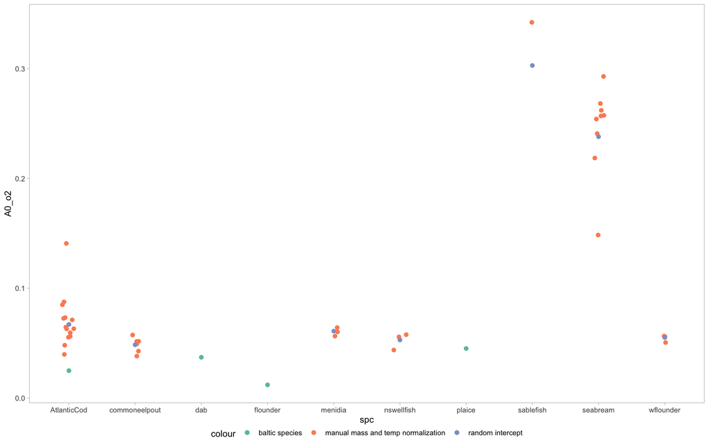

```r
ggplot(o2_og, aes(spc, A0_o2, color = "manual mass and temp normalization")) +
  geom_jitter(height = 0, width = 0.1, size = 2) +
  geom_point(data = re_o2, aes(spc, A0_o2, color = "random intercept"), size = 2) +
  geom_point(data = o2_new, aes(spc, A0_o2, color = "baltic species"), size = 2) +
  scale_color_brewer(palette = "Set2")
```

```r
# Looks good... Now we can save this dataframe and load it when we need to calculate mi in the data.
mi_params <- o2_new %>%
  dplyr::select(-b, -inv_temp, po2, o2) %>%
  mutate(n_po2 = fe_po2$n_po2,
         E_po2 = fe_po2$E_po2,
         n_o2 = fe_o2$n_o2,
         E_o2 = fe_o2$E_o2) %>%
  rename(species = spc) %>%
  mutate(species = ifelse(species == "AtlanticCod", "cod", as.character(species)))
```

```
#> mutate: new variable 'n_po2' (double) with one unique value and 0% NA
#>         new variable 'E_po2' (double) with one unique value and 0% NA
#>         new variable 'n_o2' (double) with one unique value and 0% NA
#>         new variable 'E_o2' (double) with one unique value and 0% NA
#> rename: renamed one variable (species)
#> mutate: converted 'species' from factor to character (0 new NA)
```

```r
mi_params
```

```
#> # A tibble: 4 × 10
#>   species   temp   po2    o2  A0_o2 A0_po2  n_po2 E_po2   n_o2  E_o2
#>   <chr>    <dbl> <dbl> <dbl>  <dbl>  <dbl>  <dbl> <dbl>  <dbl> <dbl>
#> 1 plaice       8  3.93  68.5 0.0451  0.669 -0.298 0.448 -0.300 0.294
#> 2 cod          8  8.42 147.  0.0249  0.370 -0.298 0.448 -0.300 0.294
#> 3 dab          8  4.44  77.4 0.0371  0.551 -0.298 0.448 -0.300 0.294
#> 4 flounder    13  4.24  65.9 0.0120  0.178 -0.298 0.448 -0.300 0.294
```

```r
write.csv(mi_params, "data/clean/mi_params.csv")
```

# Plot the metabolic index over size

```r
# Read size csv to calculate the metabolic index
sizes <- readr::read_csv("https://raw.githubusercontent.com/maxlindmark/spatial-metabolic-index/main/data/clean/sizes.csv") %>%
  mutate(group = paste(species, name, sep = "_"))
```

```
#>
#> mutate: new variable 'group' (character) with 8 unique values and 0% NA
```

```r
sizes
```

```
#> # A tibble: 8 × 6
#>   species  mat_w  max_w name         B group
#>   <chr>    <dbl>  <dbl> <chr>    <dbl> <chr>
#> 1 cod        250 17432. juvenile    50 cod_juvenile
#> 2 cod        250 17432. adult     2100 cod_adult
#> 3 dab         70   650. juvenile    30 dab_juvenile
#> 4 dab         70   650. adult      210 dab_adult
#> 5 flounder    80  2905. juvenile    30 flounder_juvenile
#> 6 flounder    80  2905. adult      500 flounder_adult
#> 7 plaice     190  5323. juvenile    60 plaice_juvenile
#> 8 plaice     190  5323. adult     1000 plaice_adult
```

```r
# Make a df from min to mat and max size
nd <- data.frame(species = rep(sizes$species, each = 50)) %>%
  mutate(b = NA,
         b = ifelse(species == "cod", seq(1, filter(sizes, species == "cod")$mat_w[1], length.out = 50), b),
         b = ifelse(species == "dab", seq(1, filter(sizes, species == "dab")$mat_w[1], length.out = 50), b),
         b = ifelse(species == "flounder", seq(1, filter(sizes, species == "flounder")$mat_w[1], length.out = 50), b),
         b = ifelse(species == "plaice", seq(1, filter(sizes, species == "plaice")$mat_w[1], length.out = 50), b)) %>%
  left_join(mi_params) %>%
  mutate(phi = A0_o2*b^n_o2) # Calculate metabolic index over size for each species at T_ref at o2 = 1
```

```
#> filter: removed 6 rows (75%), 2 rows remaining
#> filter: removed 6 rows (75%), 2 rows remaining
#> filter: removed 6 rows (75%), 2 rows remaining
#> filter: removed 6 rows (75%), 2 rows remaining
#> mutate: new variable 'b' (double) with 197 unique values and 0% NA
#>            > rows only in x     0
#>            > rows only in y  (  0)
#>            > matched rows     400
#>            >                 =====
#>            > rows total       400
#> mutate: new variable 'phi' (double) with 200 unique values and 0% NA
```

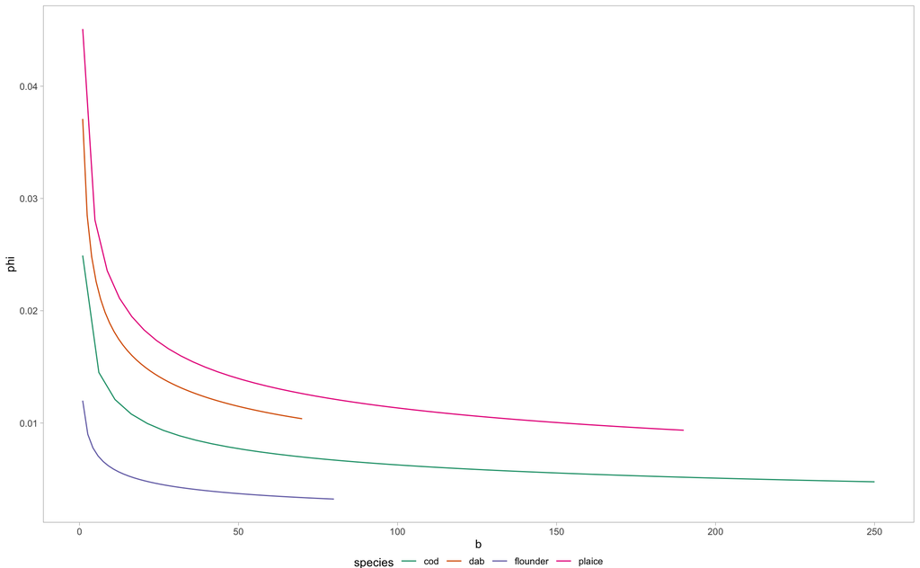

```r
ggplot(nd, aes(b, phi, color = species)) +
  scale_color_brewer(palette = "Dark2") +
  geom_line()
```

```r
# Now do for maturation size at a range of temperatures (fixed o2...)
nd2 <- data.frame(expand.grid(species = rep(sizes$species, each = 50),
                              temp = seq(10, 20, 0.2))) %>%
  mutate(inv_temp = (1 / kb)  * ( 1 / (temp + 273.15) - 1 / (tref + 273.15))) %>%
  left_join(sizes) %>%
  left_join(mi_params %>% dplyr::select(-temp), by = "species") %>%
  mutate(phi = (A0_o2*mat_w^n_o2) * exp(E_o2 * inv_temp)) # Calculate metabolic index over size for each species at T_ref at o2 = 1
```

```
#> mutate: new variable 'inv_temp' (double) with 51 unique values and 0% NA
#>            > rows only in x        0
#>            > rows only in y  (     0)
#>            > matched rows     40,800    (includes duplicates)
#>            >                 ========
#>            > rows total       40,800
#> left_join: added 8 columns (po2, o2, A0_o2, A0_po2, n_po2, …)
#>            > rows only in x        0
#>            > rows only in y  (     0)
#>            > matched rows     40,800
#>            >                 ========
#>            > rows total       40,800
#> mutate: new variable 'phi' (double) with 204 unique values and 0% NA
```

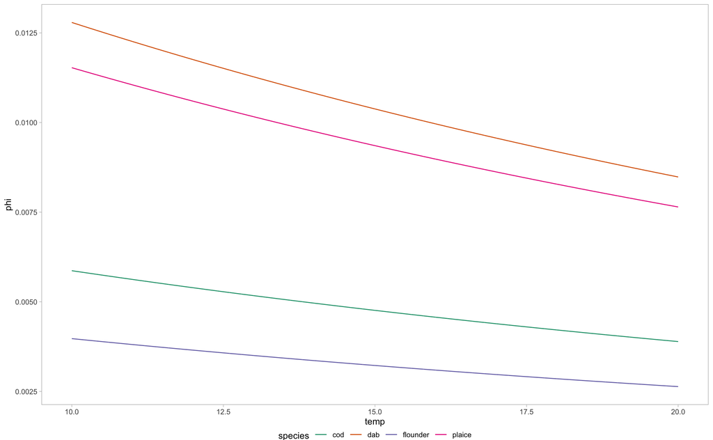

```r
ggplot(nd2, aes(temp, phi, color = species)) +
  scale_color_brewer(palette = "Dark2") +
  geom_line()
```

```r
# And lastly for the same size (10g)
nd3 <- data.frame(expand.grid(species = rep(sizes$species, each = 50),
                              temp = seq(10, 20, 0.2))) %>%
  mutate(inv_temp = (1 / kb)  * ( 1 / (temp + 273.15) - 1 / (tref + 273.15)),
         b = 10) %>%
  left_join(mi_params %>% dplyr::select(-temp), by = "species") %>%
  mutate(phi = (A0_o2*b^n_o2) * exp(E_o2 * inv_temp)) # Calculate metabolic index over size for each species at T_ref at o2 = 1
```

```
#> mutate: new variable 'inv_temp' (double) with 51 unique values and 0% NA
#>         new variable 'b' (double) with one unique value and 0% NA
#> left_join: added 8 columns (po2, o2, A0_o2, A0_po2, n_po2, …)
#>            > rows only in x        0
#>            > rows only in y  (     0)
#>            > matched rows     20,400
#>            >                 ========
#>            > rows total       20,400
#> mutate: new variable 'phi' (double) with 204 unique values and 0% NA
```

```r
# Sdd winter flounder to compare? the reason is a question whether we should use flounder data because the sizes are extremely small and when we correct we find that flounder has the lowest phi of all, when in reality it's likely most tolerant to to low oxygen and temperature. We probably should expect it to be closer to plaice or winter flounder. If we use experimental data for dab, plaice and cod they all come from the same experiment, and that's a bonus...
wflounder <- data.frame(expand.grid(species = rep("winter_flounder", each = 50),
                              temp = seq(10, 20, 0.2))) %>%
  mutate(inv_temp = (1 / kb)  * ( 1 / (temp + 273.15) - 1 / (tref + 273.15)),
         b = 10) %>%
  mutate(phi = (filter(re_o2, spc == "wflounder")$A0_o2*b^mi_params$n_o2[1]) * exp(mi_params$E_o2[1] * inv_temp))
```

```
#> mutate: new variable 'inv_temp' (double) with 51 unique values and 0% NA
#>         new variable 'b' (double) with one unique value and 0% NA
#> filter: removed 6 rows (86%), one row remaining
#> mutate: new variable 'phi' (double) with 51 unique values and 0% NA
```

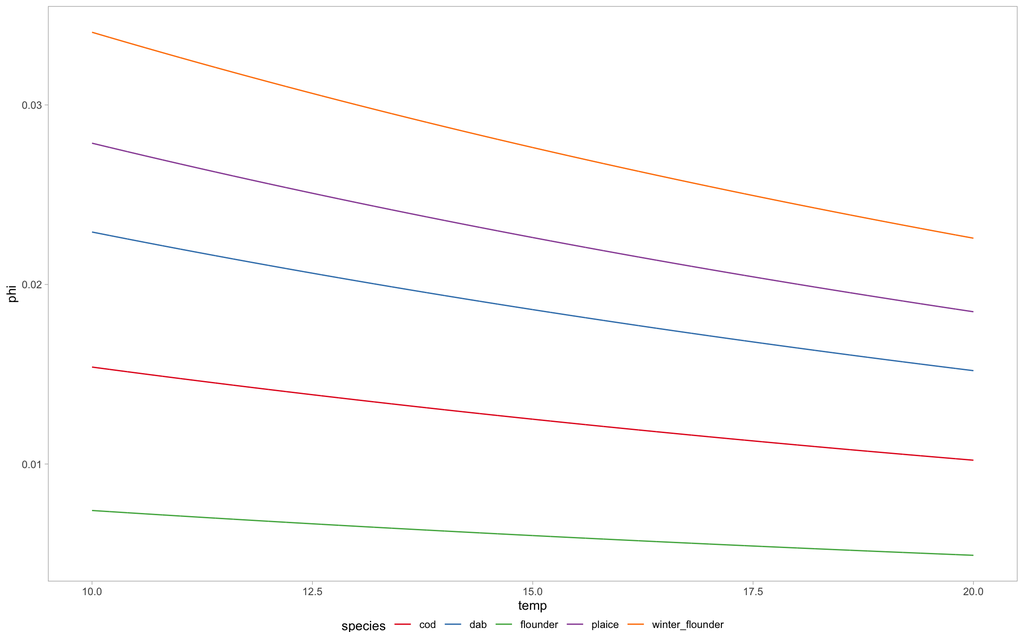

```r
nd4 <- bind_rows(nd3, wflounder)

ggplot(nd4, aes(temp, phi, color = species)) +
  scale_color_brewer(palette = "Set1") +
  geom_line()
```